# Flight delays an R analysis

Bobby Mammen

Date created: 2019-05-07

## Introduction

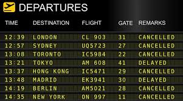

Delayed flights are a pain

**Impact of flight delays** In a study commissioned by FAA - flight delays have a major impact on the airline business and passenger time loss

“Flight delay is a serious and widespread problem in the United States. Increasing flight delays place a significant strain on the U.S. air travel system and cost airlines, passengers and society many billions of dollars each year. The $8.3 billion airline component consists of increased expenses for crew, fuel and maintenance, among others. The $16.7 billion passenger component is based on the passenger time lost due to schedule buffer, delayed flights, flight cancellations and missed connections. The $2.2 billion cost from lost demand is an estimate of the welfare loss incurred by passengers who avoid air travel as the result of delays.”

**To know more**. I am studying the flights data from NYC during 2013 to learn what are the reasons for flight delays.

**My initial hypothesis deals with 3 elements:**

1. Airport Congestion
2. Weather elements
3. Airline challenges

With These 3 elements I want to see if I can develop a Regression model that brings in these factor to say what is my average deal given the variables at the time of the departure.

## Airport Congestion

[figure not shown]

Airport congestion is one theme I have been looking into.

The best way to analyse congestion is

1. The number of flights in a given airport or
2. The number of flights leaving from an airport at any given time

I want to focus more on the number of flights leaving from an airport at any given time.

**My null hypothesis**: the number of flights leaving from an airport at any given time is not having an impact on flight delays I am looking to disprove this null hypothesis

[output not shown]

[output cut: 990 more lines]

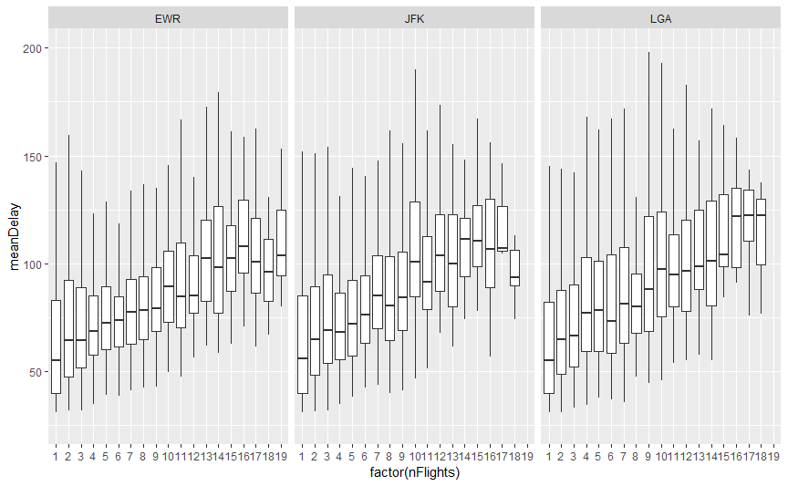

## Airline challenges

Airline challenges is the second theme I have been looking into. This theme can influence both arrival and departure delayes

There can be a number of airline issues sucj

1. The plane used by the airline is old / the engine type which could delay arrival times
2. A given plane / airline doing mutliple trips in a given days that could lead to departure delays

I want to focus more on the number of flights for a given plane if a flight has done 2 or more trips in a given day out of an airport .

**My null hypothesis**: departure delay is not influenced if a flight has done 2 or more trip in a given day out of an airport I am looking to disprove this null hypothesis

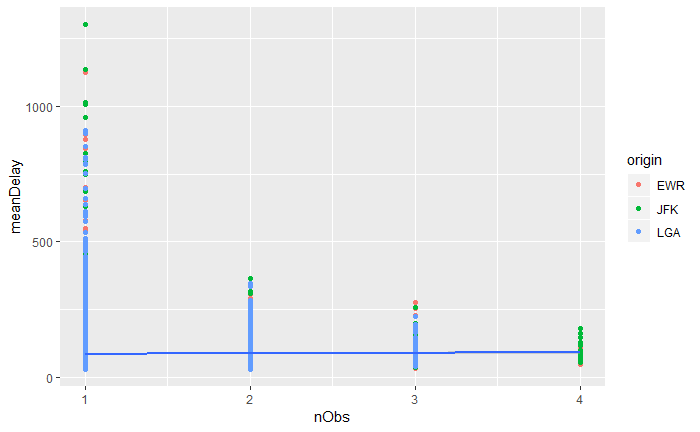